# Credit Card Users Churn Prediction

## Feature Importance

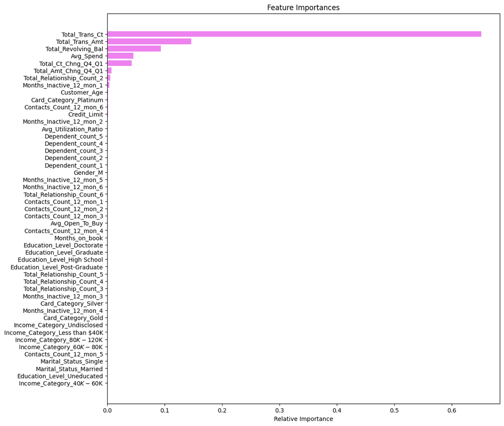

```python
feature_names = X_train.columns
importances = tuned_adb.feature_importances_
indices = np.argsort(importances)

plt.figure(figsize=(12, 12))
plt.title("Feature Importances")
plt.barh(range(len(indices)), importances[indices], color="violet", align="center")
plt.yticks(range(len(indices)), [feature_names[i] for i in indices])
plt.xlabel("Relative Importance")
plt.show()
```

- We can see that Total_Trans_Ct ,Total_Trans_Amt,Total_Revolving_Bal are the most important featuresfor making predictions.

# Business Insights and Conclusions

- Total Transaction Count is the best predictor of Customer CC Churn followed by Transaction Total Amount and these two have a strong positive co-relation as well.Customers below 50 transactions or approximately less that 3000 transaction amount tend to attrite . Marketing should aptly incentivise and promote schemes like cashback for a min transaction and /Or amount targetting increase of both transaction count and amount
- Since customer with Total Revolving Balance upto 1300 tend to Attrite more, bank can implement applying no penalty/additional interest for upto 1500 revolving balance
- Above Strategy will increase total Revolving balance which will in turn boost Avg Utilisation Ration (and average spend)
- There war 24% attrition for customers with Months _on_books at 36 months(3 years). It will be worthwhile to investigate if there are any clause or benefits that expire when the cards month on books reaches 36 monnths

*Lucrative offers for customers who have more tendency to give up the CC

- Whose Income is less than 40K
- Lower Education Level (Below Post Graduate and Doctorate)
- Who have been inactive(not used the card) for 2-3 months